# Project 4

Stats for Data Science II (STA6232)

Author

Brandy Carr

Published

March 2, 2024

#### **Recall the [Jackson Heart Study](https://www.jacksonheartstudy.org/) data from previous projects. You can find data from clinic visits 1, 2, and 3 on Canvas. For any question requiring an $\alpha$, assume $\alpha=0.05$.**

**R Code: Packages & Data Import.**

```r
library(data.table)
library(tidyverse)
library(kableExtra)
library(fastDummies)
JHS <- haven::read_sas("analysis1.sas7bdat")
```

## 1

#### **Create a variable that counts the number of controllable risk factors for stroke at visit 1.** (Note: all of the idealHealth variables indicate *ideal* health… you are being asked to count the number of *not ideal* health indicators.)

| Column | Name | Label | Uniques | NAs |
| --- | --- | --- | --- | --- |
| 165 | idealHealthSMK | Indicator for Ideal Health via Smoking Status | 2 | 41 |
| 167 | idealHealthBMI | Indicator for Ideal Health via BMI Status | 2 | 4 |
| 168 | idealHealthPA | Indicator for Ideal Health via Physical Activity Status | 2 | 2 |
| 169 | idealHealthNutrition | Indicator for Ideal Health via Nutrition Status | 2 | 241 |
| 171 | idealHealthChol | Indicator for Ideal Health via Cholesterol Status | 2 | 210 |
| 173 | idealHealthBP | Indicator for Ideal Health via BP Status | 2 | 10 |
| 175 | idealHealthDM | Indicator for Ideal Health via Glucose Status | 2 | 119 |

Figure 1: Variables

**R Code: Figure 1**

```r
Name = names(JHS)
Label = c(0); for(i in 1:length(Name)){Label[i] = (lapply(JHS, attributes))[[i]]$label}
Uniques = (lapply(JHS, function(x) length(unique(na.omit(x))))) %>% unlist(use.names=F)
NAs = (lapply(JHS, function(x) length(which(is.na(x))))) %>% unlist(use.names=F)

Meta = data.frame("Column" = c(1:length(Name)), Name, Label, Uniques, NAs)

p4Vars = (filter(Meta, Label %like% "Ideal|ideal|IDEAL" | Name %like% "Ideal|ideal|IDEAL"))

p4Vars %>%
  kbl(align=c("c","l","l","c","c")) %>%
  kable_styling("bordered") %>%
  kable_classic_2("hover") %>%
  column_spec(5, width="6em")
```

```r
JHS <- JHS %>%
          # change 0's to 1's & 1's to 0's, for all columns that start with "ideal"
          mutate(across(starts_with("ideal"), ~ifelse(.x==0, 1, ifelse(.x==1, 0, NA)))) %>%
          # create a new column named "RiskFactors" that-
          # for each row (observation), sum all the columns that start with "ideal", omitting any rows with any NAs
          mutate(RiskFactors = rowSums(select(., starts_with("ideal")), na.rm=F))

# unused kable table
# as.data.frame(JHS1 %>% select(starts_with("ideal"), RiskFactors))[1:10,] %>% kbl()

# subset data (idealHealth vars & RiskFactor var)
idealHealth_vars <- JHS %>% select(starts_with("ideal"), RiskFactors)

# renamed vars to fit on screen
names(idealHealth_vars) <- c("SMK","BMI","PA","Nutrition","Chol","BP","DM","RiskFactors")

idealHealth_vars[1:10,]
```

```
# A tibble: 10 × 8
     SMK   BMI    PA Nutrition  Chol    BP    DM RiskFactors
   <dbl> <dbl> <dbl>     <dbl> <dbl> <dbl> <dbl>       <dbl>
 1     0     1     1         1     0     0     1           4
 2     0     1     1         1     1     1     1           6
 3     0     1     0         1     0     1     0           3
 4     1     0     1         1     1     0     1           5
 5     0     1     1         1     0     1     0           4
 6     0     1     1         1     0     1     1           5
 7     0     1     1         1     0     0     1           4
 8     0     1     1         1     0     0     0           3
 9     0     1     1         1     1     1     1           6
10     1     1     1        NA     0     1     1          NA
```

## 2

#### **A. Use Poisson regression to model the count variable created in 1** (*RiskFactors*) **as a function of: age at visit 1** (*age*; years), **health insurance status at visit 1** (*PrivatePublicIns*; 0=uninsured, 1=private insurance only, 2=public insurance only, 3=private and public insurances), **education status at visit 1** (*HSgrad*; 0=did not graduate high school, 1=graduated high school)**.**

```r
JHS1 <- JHS %>%
          mutate(
            # changed to a factor, labeled levels, & renamed as Ins
            Ins = factor(PrivatePublicIns, levels=c(0,1,2,3), labels=c("Uninsured","PrivateONLY","PublicONLY","Both")),
            # changed to a factor & labeled levels
            HSgrad = factor(HSgrad, levels=c(0,1), labels=c("No","Yes")),
            # capitalized the var name
            Age = age) %>%
          select(RiskFactors, Age, Ins, HSgrad) %>%
          na.omit()

# model 1
m1 <- glm(RiskFactors ~ Age + HSgrad + Ins, data=JHS1, family="poisson")

# coefficients of model 1
c1 <- coefficients(m1)

round(t(t(c1)), 2)
```

```
                [,1]
(Intercept)     1.17
Age             0.01
HSgradYes      -0.02
InsPrivateONLY -0.06
InsPublicONLY  -0.03
InsBoth        -0.08
```

$$\large{ln \left( \hat{y} \right) = 1.17 + 0.01(Age) - 0.02(HSgrad_{Yes}) - 0.06(Ins_{PrivateONLY}) - 0.03(Ins_{PublicONLY}) - 0.08(Ins_{Both})} \tag{1}$$

$$\small{\text{coefficients displayed are rounded to 2 decimal places}}$$

#### **B. Perform the appropriate hypothesis test(s) to determine which, if any, are significant predictors of the number of controllable risk factors for stroke** (*RiskFactors*)**.**

```r
# used to determine significance for predictors: Age & HSgrad
round(summary(m1)$coeff[drop=F, c(2,3), c(3,4)], 4)
```

```
          z value Pr(>|z|)
Age        7.1884   0.0000
HSgradYes -0.6633   0.5071
```

`Age`

- Hypotheses
  - $H_{0}$ : $\beta_{Age} = 0$
  - $H_{1}$ : $\beta_{Age} \ne 0$
- Test Statistic
  - $z_{0} = 7.1884$
- P-Value
  - $p < 0.001$
- Rejection Region
  - Reject $H_{0}$ if $p < \alpha;$ $\phantom0 \alpha = 0.05$
- Conclusion
  - Reject $H_{0}$
  - There is sufficient evidence to suggest that *Age* is a significant predictor of the number of controllable risk factors for stroke (*RiskFactors*).

`HSgrad`

- Hypotheses
  - $H_{0}$ : $\beta_{HSgrad} = 0$
  - $H_{1}$ : $\beta_{HSgrad} \ne 0$
- Test Statistic
  - $z_{0} = -0.6633$
- P-Value
  - $p = 0.5071$
- Rejection Region
  - Reject $H_{0}$ if $p < \alpha;$ $\phantom0 \alpha = 0.05$
- Conclusion
  - Fail to Reject $H_{0}$
  - There is NOT sufficient evidence to suggest that graduating high school (*HSgrad*) is a significant predictor of the number of controllable risk factors for stroke (*RiskFactors*).

```r
# used to determine significance of predictor: Ins
Ins_Anova <- car::Anova(m1, type=3)[drop=F, 3, ]
attr(Ins_Anova, "heading") <- NULL
Ins_Anova
```

```
    LR Chisq Df Pr(>Chisq)
Ins   5.0109  3      0.171
```

`Ins`

- Hypotheses
  - $H_{0}$ : $\beta_{Ins_{PrivateONLY}} = \beta_{Ins_{PublicONLY}} = \beta_{Ins_{Both}} = 0$
  - $H_{1}$ : at least one $\beta_{i} \ne 0$
- Test Statistic
  - $\chi^2 = 5.0109$
- P-Value
  - $p = 0.171$
- Rejection Region
  - Reject $H_{0}$ if $p < \alpha;$ $\phantom0 \alpha = 0.05$
- Conclusion
  - Fail to Reject $H_{0}$
  - There is NOT sufficient evidence to suggest that the relationship between health insurance status (*Ins*) and the number of controllable risk factors for stroke (*RiskFactors*).

#### **C. Find the incident rate ratios and corresponding 95% CIs for the predictors.**

$$\Large{IRR_{i} = e^{\hat{\beta}_{i}}}$$

```r
round(
  cbind(
    "IRR" = exp(c1),
    "2.5%" = unname(exp(confint(m1))[,"2.5 %"]),
    "97.5%" = unname(exp(confint(m1))[,"97.5 %"])),
  2)
```

```
                IRR 2.5% 97.5%
(Intercept)    3.21 2.79  3.69
Age            1.01 1.01  1.01
HSgradYes      0.98 0.92  1.04
InsPrivateONLY 0.94 0.88  1.00
InsPublicONLY  0.97 0.89  1.06
InsBoth        0.92 0.85  1.01
```

#### **D. Provide brief interpretations of the incident rate ratios found in 2c.**

**Age:**

**HSgrad:**

- Those who graduated high school have an expected count of controllable risk factors for stroke that is 0.98 times the count for those who did not graduate high school.
- This is a 2.07% decreased.

**InsPrivateONLY:**

- Those who only carry private insurance have an expected count of controllable risk factors for stroke that is 0.94 times the count for those who are uninsured.
- This is a 5.75% decrease.

**InsPublicONLY:**

- Those who only carry public insurance have an expected count of controllable risk factors for stroke that is 0.97 times the count for those who are uninsured.
- This is a 2.58%% decrease.

**InsBoth:**

- Those who only carry both private and public insurance have an expected count of controllable risk factors for stroke that is 0.92 times the count for those who are uninsured.
- This is a 7.78%% decrease.

#### **E. Construct an appropriate data visualization to help with explaining the model results. Number of controllable risk factors for stroke should be on the y-axis and age should be on the x-axis. You choose what lines to create.**

**R Code: Click here to hide code.**

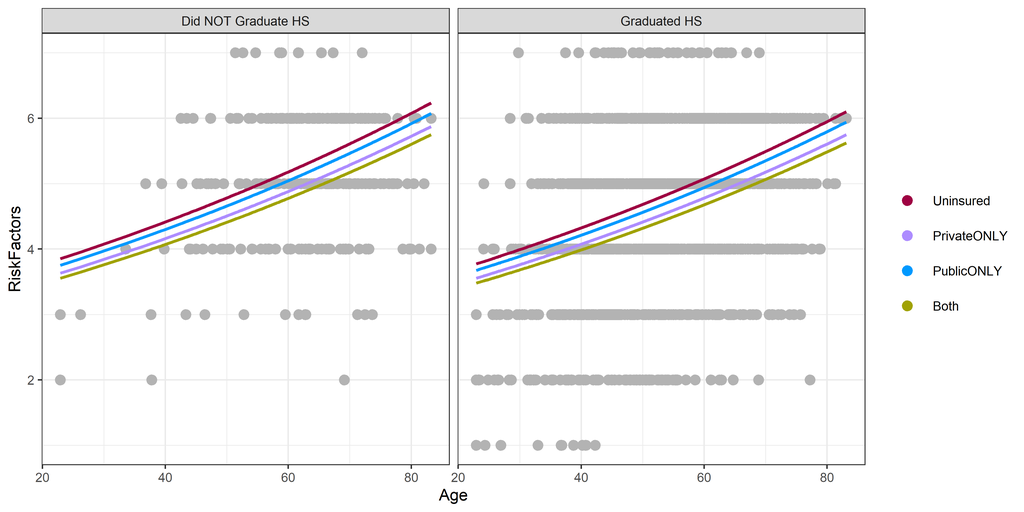

```r
JHS1 <- JHS1 %>%
  dummy_cols(select_columns = c("HSgrad","Ins")) %>%
  mutate(HSgrad_labs = ifelse(HSgrad=="Yes", "Graduated HS", "Did NOT Graduate HS"),
         yhat = exp(c1["(Intercept)"] +
                    c1["Age"]*Age +
                    c1["HSgradYes"]*HSgrad_Yes +
                    c1["InsPrivateONLY"]*Ins_PrivateONLY +
                    c1["InsPublicONLY"]*Ins_PublicONLY +
                    c1["InsBoth"]*Ins_Both),
         yhat_Ins_Uninsured = exp(c1["(Intercept)"] +
                                  c1["Age"]*Age +
                                  c1["HSgradYes"]*HSgrad_Yes +
                                  c1["InsPrivateONLY"]*0 +
                                  c1["InsPublicONLY"]*0 +
                                  c1["InsBoth"]*0),
         yhat_Ins_PrivateONLY = exp(c1["(Intercept)"] +
                                    c1["Age"]*Age +
                                    c1["HSgradYes"]*HSgrad_Yes +
                                    c1["InsPrivateONLY"]*1 +
                                    c1["InsPublicONLY"]*0 +
                                    c1["InsBoth"]*0),
         yhat_Ins_PublicONLY = exp(c1["(Intercept)"] +
                                   c1["Age"]*Age +
                                   c1["HSgradYes"]*HSgrad_Yes +
                                   c1["InsPrivateONLY"]*0 +
                                   c1["InsPublicONLY"]*1 +
                                   c1["InsBoth"]*0),
         yhat_Ins_Both = exp(c1["(Intercept)"] +
                             c1["Age"]*Age +
                             c1["HSgradYes"]*HSgrad_Yes +
                             c1["InsPrivateONLY"]*0 +
                             c1["InsPublicONLY"]*0 +
                             c1["InsBoth"]*1)) %>%
  group_by(HSgrad_labs)

  ggplot(JHS1, aes(y=RiskFactors, x=Age, group=HSgrad_labs)) +
  geom_point(aes(fill=Ins, color=Ins), size=2) +
  geom_point(size=2, color="gray70") +
  scale_fill_manual(values=c("#9E0142","#AD8CFF","#0099FF","#A0A203")) +
  scale_color_manual(values=c("#9E0142","#AD8CFF","#0099FF","#A0A203")) +
  geom_line(aes(y=yhat_Ins_Uninsured), linewidth=0.7, color="#9E0142") +
  geom_line(aes(y=yhat_Ins_PrivateONLY), linewidth=0.7, color="#AD8CFF") +
  geom_line(aes(y=yhat_Ins_PublicONLY), linewidth=0.7, color="#0099FF") +
  geom_line(aes(y=yhat_Ins_Both), linewidth=0.7, color="#A0A203") +
  labs(color="Ins", fill="Ins", group="HSgrad_labs") +
  theme_bw(base_size=8) +
  theme(legend.position="right", legend.title=element_blank()) +
  facet_wrap("HSgrad_labs", nrow=1)
```

## 3

#### **A. Use negative binomial regression to model the count variable created in 1** (*RiskFactors*) **as a function of: age** (*age*; years)**, health insurance** (*PrivatePublicIns*; 0=uninsured, 1=private insurance only, 2=public insurance only, 3=private and public insurances)**, and education status** (*HSgrad*; 0=did not graduate high school, 1=graduated high school)**.**

```r
# model 2
m2 <- MASS::glm.nb(RiskFactors ~ Age + HSgrad + Ins, data=JHS1)

# coefficients of model 2
c2 <- coefficients(m2)

round(t(t(c2)), 2)
```

```
                [,1]
(Intercept)     1.17
Age             0.01
HSgradYes      -0.02
InsPrivateONLY -0.06
InsPublicONLY  -0.03
InsBoth        -0.08
```

$$\large{ln \left( \hat{y} \right) = 1.17 + 0.01(Age) - 0.02(HSgrad_{Yes}) - 0.06(Ins_{PrivateONLY}) - 0.03(Ins_{PublicONLY}) - 0.08(Ins_{Both})} \tag{2}$$

$$\small{\text{coefficients displayed are rounded to 2 decimal places}}$$

#### **B. Compare and contrast models 2a and 3a. What do you notice?**

They result in the same model.

```r
anova(m1,m2)
```

```
Analysis of Deviance Table

Model 1: RiskFactors ~ Age + HSgrad + Ins
Model 2: RiskFactors ~ Age + HSgrad + Ins
  Resid. Df Resid. Dev Df  Deviance
1      2150     600.74
2      2150     600.73  0 0.0083118
```

#### **C. Check the assumption for Poisson regression.**

**Assumptions**

- The response variable (*RiskFactors*) is count data that appears to follow a Poisson distribution.
  - Failed to meet assumption. (see histogram below)
- $Mean = Variance$
  - Failed to meet assumption: $4.63961 \ne 1.175736$

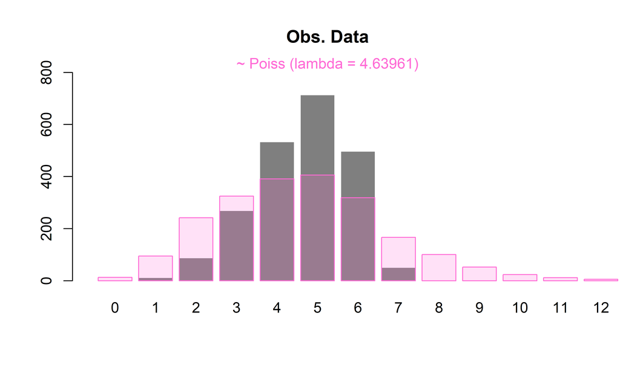

```r
x <- JHS1$RiskFactors
xbar = mean(x)
x.pois = rpois(length(x), xbar)

# HISTOGRAM OF OBSERVED DATA vs POISSON
# observed data
  barplot(c(0,unname(table(x)),rep(0,7)), main="Obs. Data", ylim=c(0,800), xlim=c(0,14), names.arg=c(0:14), col=alpha("black", 0.5), border=NA)
# simulated data
  barplot(unname(table(x.pois)), ylab="Count", xlab="Risk Factors", col=alpha("#FF6AD5", 0.2), border="#FF6AD5", add=T)
# subtitle
  text(x=7, y=830, "~ Poiss (lambda = 4.63961)", col="#FF6AD5", xpd=T)
```

**R Code: Extra.**

```r
sx = sd(x)

x.nbinom = rnbinom(length(x), max(x), xbar/max(x))
x.binom = rbinom(length(x), max(x), xbar/max(x))
x.norm = rnorm(length(x), xbar, sx)

ks.test(x, x.pois, alternative = "two.sided", simulate.p.value = T)$p.value
ks.test(x, x.nbinom, alternative = "two.sided", simulate.p.value = T)$p.value
ks.test(x, x.binom, alternative = "two.sided", simulate.p.value = T)$p.value

# NEG BINOM
barplot(c(0,unname(table(x)),rep(0,7)), main="Obs. Data", ylim=c(0,800), xlim=c(0,14), names.arg=c(0:14), col=alpha("black", 0.5), border=NA)
barplot(unname(table(x.nbinom)), ylab="Count", xlab="Risk Factors", col=alpha("#FF6AD5", 0.2), border="#FF6AD5", add=T)
text(x=7, y=830, "~ NegBinom (r = 7,  p = 0.6628)", col="#FF6AD5", xpd=T)

# BINOM
barplot(c(0,unname(table(x)),rep(0,7)), main="Obs. Data", ylim=c(0,800), xlim=c(0,14), names.arg=c(0:14), col=alpha("black", 0.5), border=NA)
barplot(c(0,unname(table(x.binom))), ylab="Count", xlab="Risk Factors", col=alpha("#A0A203", 0.2), border="#A0A203", add=T)
text(x=7, y=830, "~ Binom (n = 7,  p = 0.6628)", col="#A0A203", xpd=T)
```

[output not shown]

#### **D. Use your response in 3c to explain your observations in 3b.**

RiskFactors is bounded above, at 7. Data more closely follows a binom distribution.